# General Analysis of Global Happiness Scores

I first wanted to look at the general analysis of the data and see if the happiness scores displayed similar levels in neighboring countries.

### Descriptive Statistics

```r
# Load libraries
library(tidyverse)
library(sf)
library(spdep)
library(viridis)
library(readxl)
library(rnaturalearth)
library(rnaturalearthdata)
library(corrplot)
```

```r
# Load spatial and happiness datasets
world_sf <- rnaturalearth::ne_countries(scale = "medium", returnclass = "sf")
happiness_data <- read_excel("../data/WHR20_DataForTable2.1.xls")
```

```r
# Summary of numeric variables
summary(select_if(happiness_data, is.numeric))
```

```
      year       Life Ladder    Log GDP per capita Social support
 Min.   :2005   Min.   :2.375   Min.   : 6.457     Min.   :0.2902
 1st Qu.:2010   1st Qu.:4.623   1st Qu.: 8.309     1st Qu.:0.7483
 Median :2013   Median :5.363   Median : 9.408     Median :0.8340
 Mean   :2013   Mean   :5.446   Mean   : 9.245     Mean   :0.8111
 3rd Qu.:2016   3rd Qu.:6.268   3rd Qu.:10.209     3rd Qu.:0.9046
 Max.   :2019   Max.   :8.019   Max.   :11.728     Max.   :0.9873
                                NA's   :29         NA's   :13
 Healthy life expectancy at birth Freedom to make life choices
 Min.   :32.30                    Min.   :0.2575
 1st Qu.:58.30                    1st Qu.:0.6431
 Median :65.10                    Median :0.7575
 Mean   :63.17                    Mean   :0.7385
 3rd Qu.:68.39                    3rd Qu.:0.8524
 Max.   :77.10                    Max.   :0.9852
 NA's   :52                       NA's   :31
   Generosity       Perceptions of corruption Positive affect
 Min.   :-0.33177   Min.   :0.0352            Min.   :0.3217
 1st Qu.:-0.11718   1st Qu.:0.6927            1st Qu.:0.6233
 Median :-0.02372   Median :0.8036            Median :0.7208
 Mean   : 0.00011   Mean   :0.7491            Mean   :0.7096
 3rd Qu.: 0.09115   3rd Qu.:0.8737            3rd Qu.:0.8011
 Max.   : 0.67992   Max.   :0.9833            Max.   :0.9436
 NA's   :83         NA's   :103               NA's   :21
 Negative affect   Confidence in national government Democratic Quality
 Min.   :0.08343   Min.   :0.06877                   Min.   :-2.4483
 1st Qu.:0.20595   1st Qu.:0.33641                   1st Qu.:-0.7885
 Median :0.25577   Median :0.46479                   Median :-0.2259
 Mean   :0.26721   Mean   :0.48316                   Mean   :-0.1350
 3rd Qu.:0.31800   3rd Qu.:0.61626                   3rd Qu.: 0.6531
 Max.   :0.70459   Max.   :0.99360                   Max.   : 1.5825
 NA's   :15        NA's   :191                       NA's   :149
 Delivery Quality   Standard deviation of ladder by country-year
 Min.   :-2.14497   Min.   :0.863
 1st Qu.:-0.71114   1st Qu.:1.747
 Median :-0.21663   Median :1.987
 Mean   :-0.00209   Mean   :2.052
 3rd Qu.: 0.69965   3rd Qu.:2.280
 Max.   : 2.18472   Max.   :4.073
 NA's   :148
```

[output cut: 73 more lines]

```
 Min.   :0.0382
 1st Qu.:0.1435
 Median :0.1984
 Mean   :0.2643
 3rd Qu.:0.3914
 Max.   :0.7373
 NA's   :1164
 Most people can be trusted, WVS round 2010-2014
 Min.   :0.0315
 1st Qu.:0.1187
 Median :0.1935
 Mean   :0.2372
 3rd Qu.:0.3350
 Max.   :0.6618
 NA's   :1124
```

```r
# Check for missing values
missing_data <- sapply(happiness_data, function(x) sum(is.na(x)))
print(missing_data)
```

```
                                                         Country name
                                                                    0
                                                                 year
                                                                    0
                                                          Life Ladder
                                                                    0
                                                   Log GDP per capita
                                                                   29
                                                       Social support
                                                                   13
                                     Healthy life expectancy at birth
                                                                   52
                                         Freedom to make life choices
                                                                   31
                                                           Generosity
                                                                   83
                                            Perceptions of corruption
                                                                  103
                                                      Positive affect
                                                                   21
                                                      Negative affect
                                                                   15
                                    Confidence in national government
                                                                  191
                                                   Democratic Quality
                                                                  149
                                                     Delivery Quality
                                                                  148
                         Standard deviation of ladder by country-year
                                                                    0
                    Standard deviation/Mean of ladder by country-year
                                                                    0
                                     GINI index (World Bank estimate)
                                                                 1133
GINI index (World Bank estimate), average 2000-2017, unbalanced panel
                                                                  180
             gini of household income reported in Gallup, by wp5-year
                                                                  370
                                   Most people can be trusted, Gallup
                                                                 1668
                      Most people can be trusted, WVS round 1981-1984
                                                                 1712
                      Most people can be trusted, WVS round 1989-1993
                                                                 1611
                      Most people can be trusted, WVS round 1994-1998
                                                                 1181
                      Most people can be trusted, WVS round 1999-2004
                                                                 1319
                      Most people can be trusted, WVS round 2005-2009
                                                                 1164
                      Most people can be trusted, WVS round 2010-2014
                                                                 1124
```

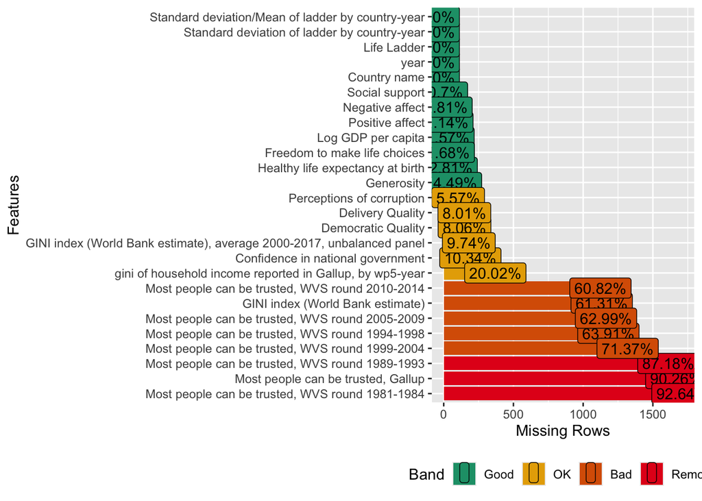

```r
# Visualize missing data
library(DataExplorer)
plot_missing(happiness_data)
```

### Visualization of Global Happiness Distribution

```r
# Select relevant columns
happiness_data <- happiness_data %>%
  select(
    `year`, `Country name`, `Life Ladder`, `Log GDP per capita`, `Social support`, `Freedom to make life choices`, `Healthy life expectancy at birth`,
    `Generosity`, `Perceptions of corruption`, `Democratic Quality`, `Delivery Quality`, `GINI index (World Bank estimate), average 2000-2017, unbalanced panel`,
    `Confidence in national government`, `gini of household income reported in Gallup, by wp5-year`
  )

happiness_data <- happiness_data %>%
  rename(`gini of income` = `gini of household income reported in Gallup, by wp5-year`)
```

```r
# Ensure the Life Ladder column is numeric
happiness_data <- happiness_data %>%
  mutate(`Life Ladder` = as.numeric(`Life Ladder`))
```

```r
# Merge spatial and happiness data
merged_sf <- left_join(world_sf, happiness_data, by = c("name" = "Country name"))
merged_sf <- merged_sf[!is.na(merged_sf$`Life Ladder`), ] # Remove rows with missing happiness scores
```

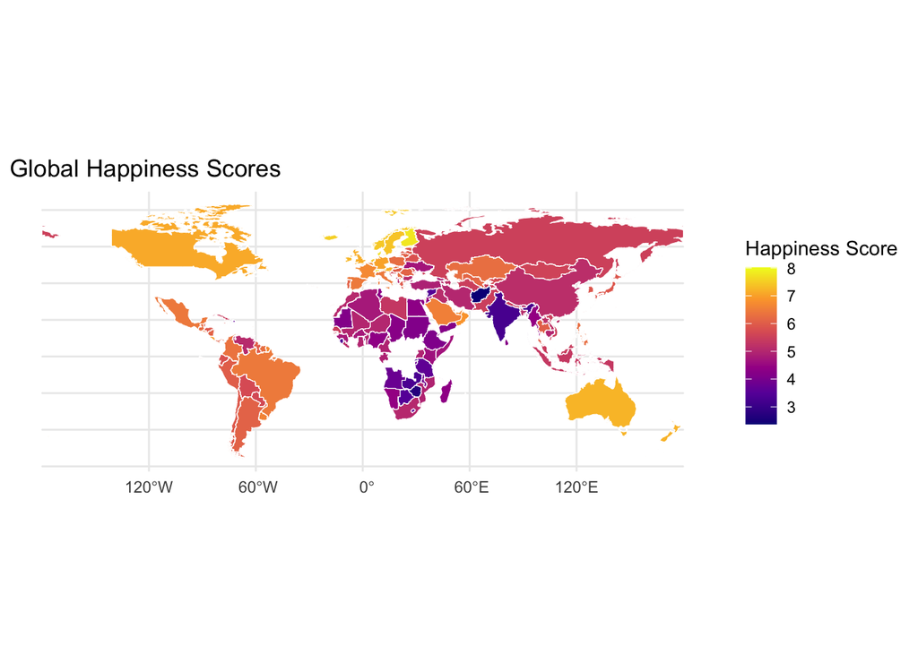

```r
# Plot happiness scores globally
ggplot(data = merged_sf) +
  geom_sf(aes(fill = `Life Ladder`), color = "white") +
  scale_fill_viridis_c(option = "C", na.value = "gray") +
  theme_minimal() +
  labs(title = "Global Happiness Scores", fill = "Happiness Score")
```

Choropleth maps were used to visualize the global distribution of happiness scores. The maps revealed clear spatial patterns, with higher happiness levels concentrated in economically advanced regions such as Western Europe and North America. Conversely, lower scores were observed in regions facing socioeconomic challenges, such as parts of Africa and the Middle East. This visualization highlights the stark contrasts in global happiness and sets the stage for deeper spatial statistical exploration.

### Spatial Autocorrelation and Clustering

```r
# Compute k-nearest neighbors (k = 5)
coords <- st_coordinates(st_centroid(merged_sf))
knn <- spdep::knearneigh(coords, k = 5)
listw_knn <- spdep::nb2listw(spdep::knn2nb(knn), style = "W")

# Compute Global Moran's I
moran_global <- spdep::moran.test(merged_sf$`Life Ladder`, listw_knn)
print(moran_global)
```

```
    Moran I test under randomisation

data:  merged_sf$`Life Ladder`
weights: listw_knn

Moran I statistic standard deviate = 66.484, p-value < 2.2e-16
alternative hypothesis: greater
sample estimates:
Moran I statistic       Expectation          Variance
     0.8764184639     -0.0005885815      0.0001740068
```

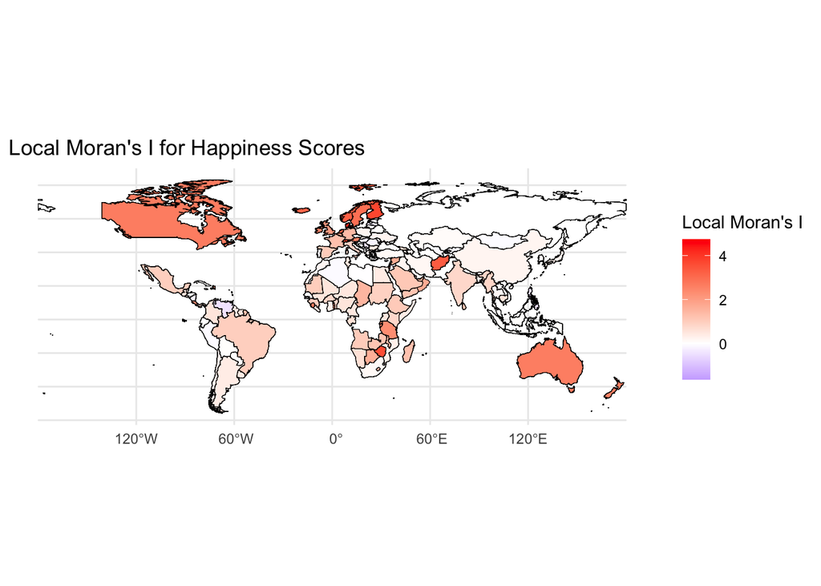

```r
# Compute Local Moran's I
local_moran <- spdep::localmoran(merged_sf$`Life Ladder`, listw_knn)

# Add results to the spatial dataframe
merged_sf$Ii <- local_moran[, "Ii"]
merged_sf$p_value <- local_moran[, "Pr(z != E(Ii))"]

# Plot Local Moran's I
ggplot(merged_sf) +
  geom_sf(aes(fill = Ii), color = "black") +
  scale_fill_gradient2(low = "blue", mid = "white", high = "red", midpoint = 0) +
  theme_minimal() +
  labs(title = "Local Moran's I for Happiness Scores", fill = "Local Moran's I")
```

```r
# Add significance column (assuming p_value exists)
merged_sf$significance <- ifelse(merged_sf$p_value < 0.05, "Significant", "Not Significant")
```

[figure not shown]

```r
ggplot() +
  geom_sf(data = merged_sf, aes(fill = `Life Ladder`), color = NA, alpha = 0.8) +
  geom_sf(data = merged_sf, aes(color = significance), size = 0.3) +
  scale_fill_viridis_c(option = "C", name = "Happiness Score", alpha = 0.8) +
  scale_color_manual(
    values = c("Significant" = "red", "Not Significant" = "transparent"),
    name = "Moran's I Significance"
  ) +
  theme_minimal() +
  labs(title = "Overlay of Happiness Scores and Moran's I Clusters")
```

[output not shown]

To investigate spatial relationships, Moran’s I was calculated. The global Moran’s I statistic (0.876, p-value < 2.2e-16) confirmed strong spatial clustering of happiness scores, indicating that neighboring countries tend to exhibit similar happiness levels. Local Moran’s I further identified specific hotspots (clusters of high happiness scores) and coldspots (clusters of low scores). These localized clusters provide actionable insights into regions where happiness is either thriving or lagging, with the possibility of being linked to economic, political, or social conditions.

## Hotspot Analysis and Regional Trends

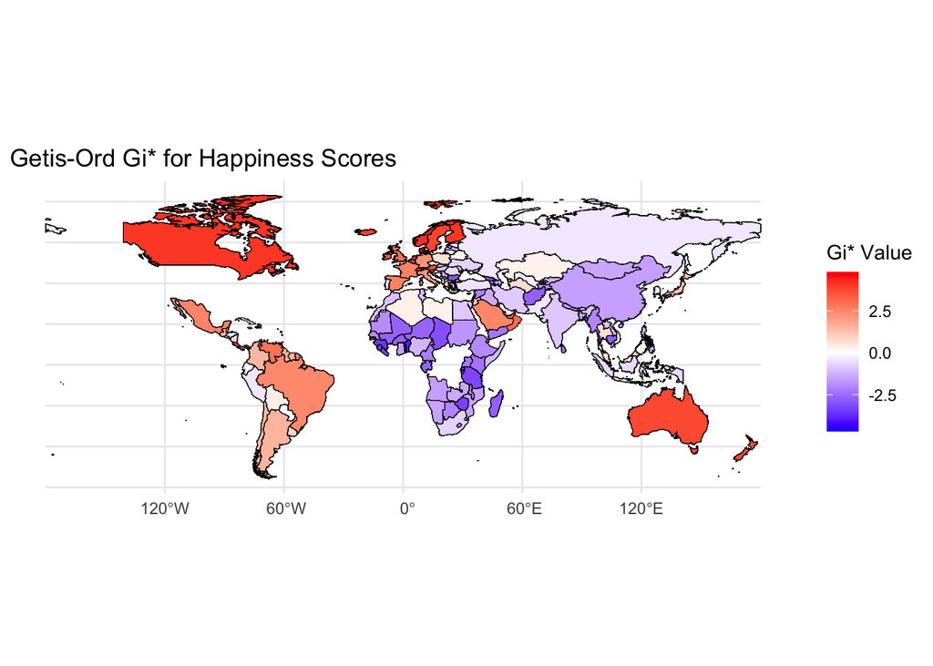

```r
# Compute Getis-Ord Gi* and convert to numeric
merged_sf$Gi_star <- as.numeric(spdep::localG(merged_sf$`Life Ladder`, listw_knn))

# Plot hotspots and coldspots
ggplot(merged_sf) +
  geom_sf(aes(fill = Gi_star), color = "black") +
  scale_fill_gradient2(low = "blue", mid = "white", high = "red", midpoint = 0) +
  theme_minimal() +
  labs(
    title = "Getis-Ord Gi* for Happiness Scores",
    fill = "Gi* Value"
  )
```

The Getis-Ord Gi* statistic was applied to detect spatial hotspots and coldspots of happiness scores. High-value hotspots often corresponded to regions with robust economic performance and social cohesion, such as Scandinavia and parts of North America. In contrast, coldspots aligned with areas grappling with instability or poverty. An overlay map combined happiness scores with clusters identified through Moran’s I, confirming the findings.